# La revolución del triple en la NBA

2019-12-15

## INTRODUCCIÓN

- Queremos estudiar cómo los equipos han pasado de tirar muy poquito de tres a tirar tanto como ahora
- Para que os hagáis una idea de esta evolución, jugadores con más triples anotados en estas temporadas

| Season | Player | TPA |
| --- | --- | --- |
| 1980-81 | Mike Bratz | 57 |
| 1990-91 | Vernon Maxwell | 172 |
| 2015-16 | Stephen Curry | 402 |
| 2018-19 | James Harden | 378 |

- Los datos los hemos descargado de [BasketballReference](https://www.basketball-reference.com/)

## PRIMERA VISUALIZACIÓN

[figure not shown]

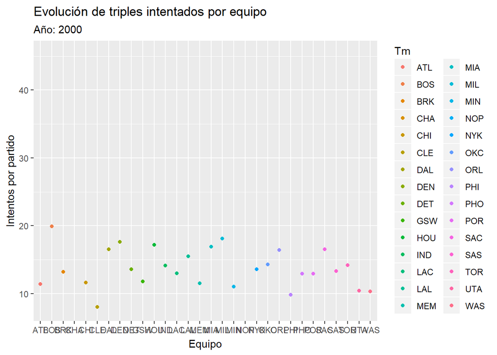

## SEPARACIÓN POR DIVISIONES

- En la NBA, los equipos están divididos geográficamente por conferencias, y éstas por divisiones, habiendo un total de 6 divisiones de 5 equipos cada una.
- Para hacerlo, asignamos a cada equipo a su estado y a su división y quedaría algo así.

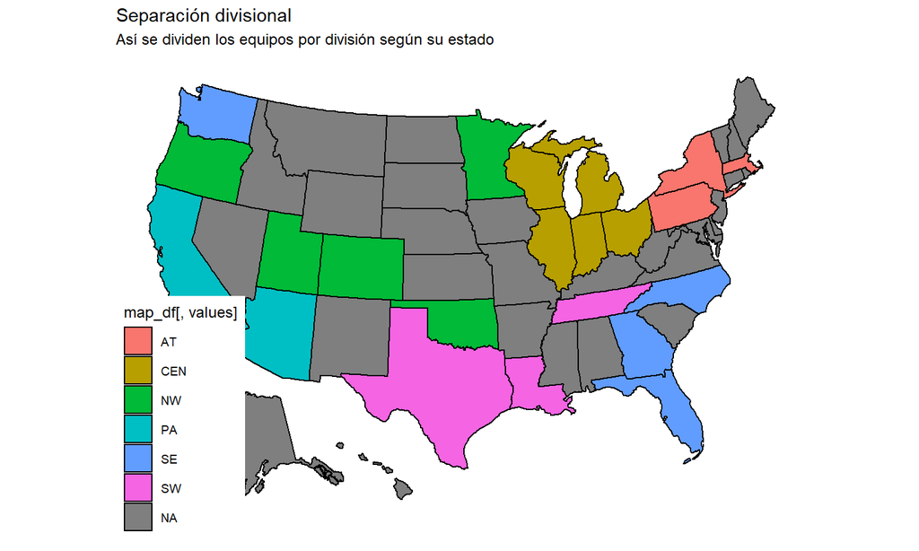

## EVOLUCIÓN

- Vemos cómo no solo se ha evolucionado hacia tirar más triples, si no también a tirar menos de dos.

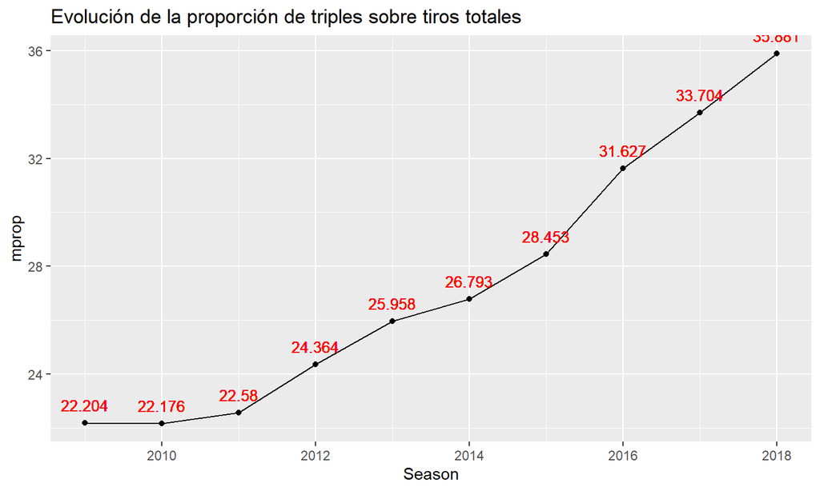

- Sería lógico hacerse la siguiente pregunta: Aparte de tirar más, ¿se tira mejor? ¿Viene este incremento del número de triples intentados acompañado de un aumento de los porcentajes de tiro?

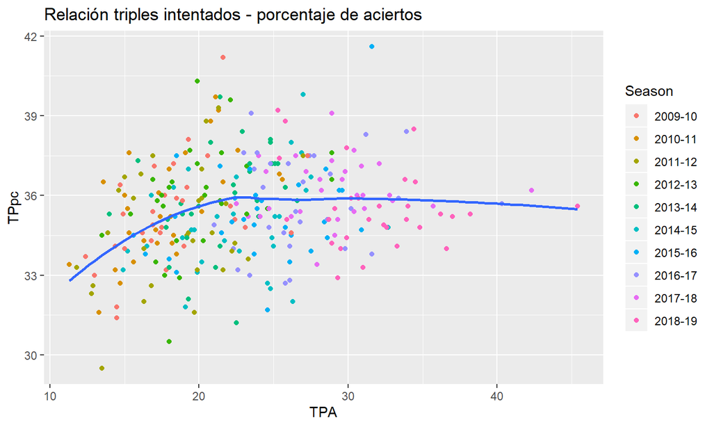

- Hacemos una regresión lineal y vemos los resultados

| Observations | 300 |
| --- | --- |
| Dependent variable | TPpc |
| Type | OLS linear regression |

| F(1,298) | 18.50 |
| --- | --- |
| R² | 0.06 |
| Adj. R² | 0.06 |

|  | Est. | S.E. | t val. | p |
| --- | --- | --- | --- | --- |
| (Intercept) | 33.77 | 0.41 | 81.94 | 0.00 |
| TPA | 0.07 | 0.02 | 4.30 | 0.00 |

Standard errors: OLS

[figure not shown]

- Vemos que hay un **desplazamiento diagonal**, lo que nos hace pensar que sí, ambas variables estarían relacionadas.

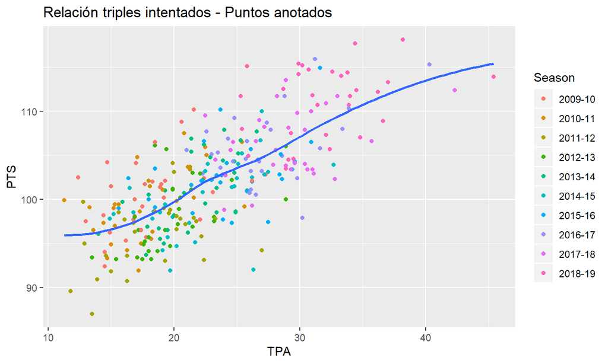

## REGRESIÓN

- Como antes, hacemos una regresión

| Observations | 300 |
| --- | --- |
| Dependent variable | PTS |
| Type | OLS linear regression |

| F(1,298) | 352.21 |
| --- | --- |
| R² | 0.54 |
| Adj. R² | 0.54 |

|  | Est. | S.E. | t val. | p |
| --- | --- | --- | --- | --- |
| (Intercept) | 85.69 | 0.90 | 94.73 | 0.00 |
| TPA | 0.71 | 0.04 | 18.77 | 0.00 |

Standard errors: OLS

- Clave: más **velocidad**

## TABLAS

- Por último, vamos a acabar con unas tablas para acabar de observar los datos sobre el rendimiento de los equipos en este periodo desde 2010, a partir de esta “revolución del triple”.

### MÁS TRIPLES INTENTADOS POR PARTIDO

| pos | Season | Tm | TPA |
| --- | --- | --- | --- |
| 1 | 2018-19 | HOU | 45.4 |
| 2 | 2017-18 | HOU | 42.3 |
| 3 | 2016-17 | HOU | 40.3 |
| 4 | 2018-19 | MIL | 38.2 |
| 5 | 2018-19 | ATL | 37.0 |

**¿Qué equipos han lanzado más triples por partido durante una temporada desde 2010?**

**1 - 3**:

[figure not shown]

### MÁS TRIPLES ANOTADOS POR PARTIDO

| pos | Season | Tm | TP |
| --- | --- | --- | --- |
| 1 | 2018-19 | HOU | 16.1 |
| 2 | 2017-18 | HOU | 15.3 |
| 3 | 2016-17 | HOU | 14.4 |
| 4 | 2018-19 | MIL | 13.5 |
| 5 | 2018-19 | GSW | 13.3 |

**¿Qué equipos han anotado más triples por partido durante una temporada desde 2010?**

**1 - 3**:

[figure not shown]

### MEJOR PORCENTAJE DE TRIPLES

| pos | Season | Tm | TPpc |
| --- | --- | --- | --- |
| 1 | 2015-16 | GSW | 41.6 |
| 2 | 2009-10 | PHO | 41.2 |
| 3 | 2012-13 | GSW | 40.3 |
| 4 | 2014-15 | GSW | 39.8 |
| 5 | 2013-14 | SAS | 39.7 |

**¿Qué equipos han tirado mejor de tres durante una temporada desde 2010?**

**1**:

[figure not shown]

**2**:

[figure not shown]

**3**:

[figure not shown]

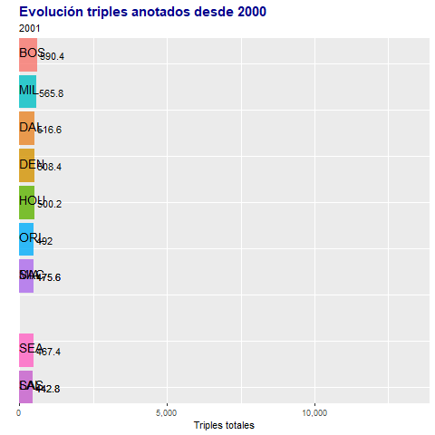

[figure not shown]